# Lab 4

Ritali Jain

2/14/2022

# Lab 4: Z-Test, T-Test, and Chi-Square

```r
#Load libraries
library("BSDA")
```

```r
library("ggplot2")
#Load datasets
fly.hindleg.RSPM.df <- read.csv("fly_hindleg_RSPM.csv")
expected.frequencies.df <- read.csv("expected_frequencies.csv", row.names=1)
fly.interbeat.df <- read.csv("fly_interbeat.csv")
antennae.DEGs.df <- read.csv("antennae_DEGs.csv")
```

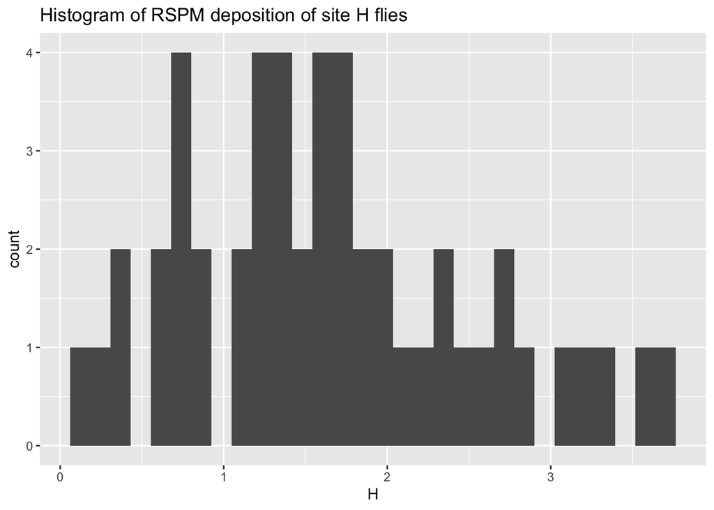

```r
#Plot histograms of RSPM deposition to determine which site has more normal data
ggplot(data=fly.hindleg.RSPM.df, aes(x=H)) +
  geom_histogram() +
  ggtitle("Histogram of RSPM deposition of site H flies") +
  xlab("H") +
  ylab("count")
```

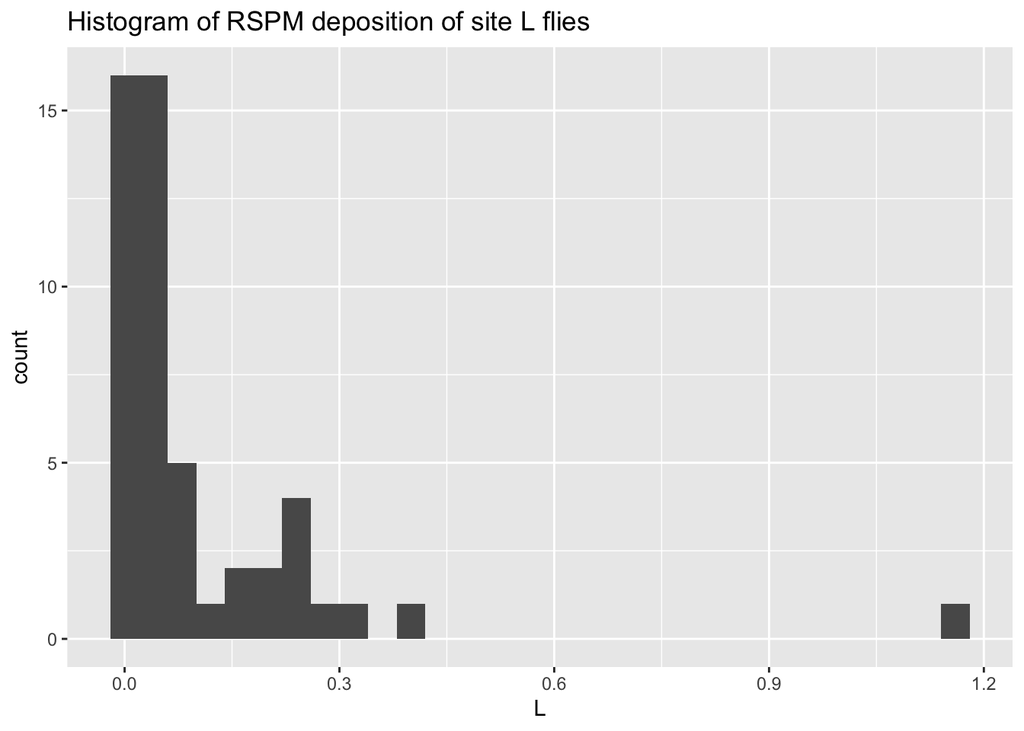

```r
ggplot(data=fly.hindleg.RSPM.df, aes(x=L)) +
  geom_histogram() +
  ggtitle("Histogram of RSPM deposition of site L flies") +
  xlab("L") +
  ylab("count")
```

```r
#Quantify normality using Shapiro-Wilk test
#Note: For this test, the null hypothesis is that the data are normal, so a high p-value suggests normal distribution.
high <- fly.hindleg.RSPM.df$H
low <- fly.hindleg.RSPM.df$L
shapiro.test(high) #shapiro test for H column
```

```
##
##  Shapiro-Wilk normality test
##
## data:  high
## W = 0.96689, p-value = 0.1725
```

```r
shapiro.test(low) #shapiro test for L column
```

```
##
##  Shapiro-Wilk normality test
##
## data:  low
## W = 0.53379, p-value = 2.277e-11
```

## Q1

Based on the histograms and the Shapiro-Wilk tests, the high pollution site has more normal data. The high pollution site histogram has more of a bell-shaped curve while the low pollution site histogram is far more positively skewed. Furthermore, the p-value for the high pollution site Shapiro-Wilk test is greater than the p-value of the low site pollution Shapiro-Wilk test (0.1725 > 2.277e-11). A higher p-value for this test suggests normal distribution.

## Q2

Null Hypothesis: The mean from the high pollution site sample is equal to 0. (mu = 0)

Alternative Hypothesis: The mean from the high pollution site sample is not equal to 0. (mu != 0)

```r
#Z-Test
z.test(x=high, y = NULL, alternative = "two.sided", mu = 0, sigma.x
= sd(high), sigma.y = NULL, conf.level = 0.95)
```

```
##
##  One-sample z-Test
##
## data:  high
## z = 13.385, p-value < 2.2e-16
## alternative hypothesis: true mean is not equal to 0
## 95 percent confidence interval:
##  1.428306 1.918361
## sample estimates:
## mean of x
##  1.673333
```

```r
#Note for sigma.x argument: Since the sample size is >30, assume that the sample standard deviation is a close-enough estimate of the population standard deviation.
```

## Q3.

I would reject the null hypothesis based on the alpha of 0.05 and the p-value from the z-test result. The p-value is less than the alpha significance level (2.2e-16 < 0.05).

```r
#There’s a fruit fly exposed to the highly-polluted site that has a hindleg RSPM deposition of 1%. What percentage of fruit flies exposed to the same site have a lower hindleg RSPM deposition? Determine this using the z-score, which you’ll need to calculate yourself for this individual fruit fly.

z.score.fly <- (1-mean(high))/sd(high)
z.score.fly
```

```
## [1] -0.7616909
```

## Q4.

Question: There’s a fruit fly exposed to the highly-polluted site that has a hindleg RSPM deposition of 1%. What percentage of fruit flies exposed to the same site have a lower hindleg RSPM deposition? Determine this using the z-score, which you’ll need to calculate yourself for this individual fruit fly.

Answer: The z-score for this fly is -0.7616909, which is 27.64% to the mean from this fly. The percentage of fruit flies with lower hindleg RSPM deposition is 50% - 27.64% = 22.36%.

```r
# Quantifying normality on the fly interbeat data
unexposed <- fly.interbeat.df$U
high <- fly.interbeat.df$H
low <- fly.interbeat.df$L

shapiro.test(unexposed)
```

```
##
##  Shapiro-Wilk normality test
##
## data:  unexposed
## W = 0.96597, p-value = 0.6686
```

```r
shapiro.test(low)
```

```
##
##  Shapiro-Wilk normality test
##
## data:  low
## W = 0.90526, p-value = 0.05181
```

```r
shapiro.test(high)
```

```
##
##  Shapiro-Wilk normality test
##
## data:  high
## W = 0.92156, p-value = 0.1062
```

## Q5

Null Hypothesis: The mean of the standard deviations of interbeat intervals of high-exposure fruit flies is equal to that of low-exposure fruit flies. (mu high = mu low)

Alternative Hypothesis: The mean of the standard deviations of interbeat intervals of high-exposure fruit flies is not equal to that of low-exposure fruit flies. (mu high != mu low)

```r
#Conduct Two Sample t-test on high and low samples
t.test(x=low, y=high, var.equal=TRUE)
```

```
##
##  Two Sample t-test
##
## data:  low and high
## t = -1.7669, df = 38, p-value = 0.08527
## alternative hypothesis: true difference in means is not equal to 0
## 95 percent confidence interval:
##  -67.44625   4.58040
## sample estimates:
## mean of x mean of y
##  109.9695  141.4024
```

## Q6

This test was a two-sample t-test because we are determining if two population means (mean from the high pollution site and mean from the low pollution site) are different. It is not a one-sample test because we are not comparing if the population mean of one sample differs from a given value. It is also not paired because the means have samples that are independent of each other.

## Q7

I would not reject the null hypothesis because the p-value is greater than our alpha significance level of 0.05. (0.085 > 0.05)

## Q8.

The “Respiratory and circulatory physiology and immunology” subsection in Results and Discussions of the paper would tell us whether there was a significant difference between the SD interbeat intervals of unexposed, low-exposure, or high-exposure fruit flies. In fact, in this section the authors write: “the mean SD of interbeat interval of heart rate (IBI), an alternate method and an indicator of arrhythmicity (50), was significantly different for bees collected from the highly polluted site (Welch ANOVA test followed by Dunnett’s T3 multiple comparisons test).”

```r
# Create frequencies for the observed DEGs data
observed.frequencies <- table(antennae.DEGs.df$Functions)
observed.frequencies["Other"] <- 0

# Normalize the observed and expected frequencies using proportions
observed.normalized <- observed.frequencies/sum(observed.frequencies)
expected.normalized <- expected.frequencies.df$Genome.frequency/sum(expected.frequencies.df$Genome.frequency)
```

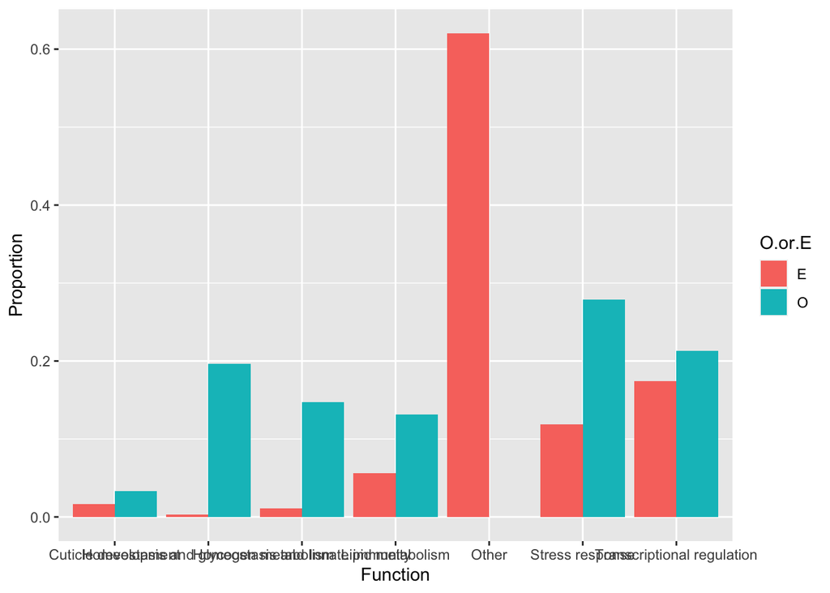

```r
# Combining the data into a data frame for ggplot
chi.bar.data <- data.frame( "Function"=rep(rownames(expected.frequencies.df), 2),
  "O.or.E"=c(rep("O",7),rep("E",7)),
  "Proportion"=c(observed.normalized,expected.normalized))

# Generating the plot
ggplot(data=chi.bar.data, aes(x=Function, y=Proportion, fill=O.or.E)) +
  geom_col(position="dodge")
```

## Q9

I think this figure is interesting because the expected frequency for ‘Other’ functions is greater than 0.6, but the observed frequency is zero. Another interesting observation is that the frequency for ‘Homeostasis and glycogen metabolism’ is expected to be around zero, but the observed frequency is approximately 0.2.

```r
specific.function <- "Stress response"
```

## Q10

Null Hypothesis: The observed frequency proportion for Stress Response is equal to the expected frequency proportion. (observed = expected)

Alternative Hypothesis: The observed frequency proportion for Stress Response is not equal to the expected frequency proportion. (observed != expected)

## Q11

This is a goodness-of-fit test. We are determining how closely the observed data matches the expected data.

```r
specific.observed <- c( observed.frequencies[specific.function], sum(observed.frequencies) - observed.frequencies[specific.function] )

specific.expected <- c( expected.frequencies.df[specific.function,], sum(expected.frequencies.df) - expected.frequencies.df[specific.function,])
```

## Q12

This code creates two vectors. One is for the observed frequencies and one for the expected frequencies. The first value in the vector is the frequency of the specific function being examined (in this case stress response) and the second value in the vector is the frequency of all other functions.

## Q13

The rescale.p = TRUE in the chisq.test() rescales the values in the specific.expected vector so that they add up to 1.

```r
chisq.test( specific.observed, p=specific.expected, correct=FALSE, rescale.p = TRUE)
```

```
##
##  Chi-squared test for given probabilities
##
## data:  specific.observed
## X-squared = 14.891, df = 1, p-value = 0.0001139
```

## Q14

Calculating the degrees of freedom for a goodness-of-fit test is: Df = (2-1)(columns-1) = n-1. So, since we have two observations (frequency of stress response and frequency of functions other than stress response), df = 2-1 = 1.

## Q15

I would reject the null hypothesis because the p-value is 0.0001139, which is smaller than the alpha significance level of 0.05.